# NRH Vent Weaning

Author

Brian Locke

## Data Cleaning

Import needed utilities and the data to a tbl named df

Drop un-needed columns for current analysis:

```r
df <- df_orig |>
  select(-PAT_MRN_ID, -`Date of Injury`, -Column1, -Comments)
#Getting rid of date for now, though might be of use later - would need to figure out how to convert the dates.
```

Rename variables to usual R syntax

```r
df <- df |>
  rename(age = Age,
         female = Sex,
         prior_inj_level = `Injury Level reported prior to rehab`,
         rib_fx = `Rib fractures (Y or N)`,
         ptx = `Pneumothorax (Y or N)`,
         chest_tube = `Chest tube (Y or N)`,
         days_inj_intub = `Days from injury to intubation`,
         reason_intub = `Reason for Intubation`,
         days_intub_trach = `Days from intubation to Trach`,
         wean_before_trach = `Attempt to wean prior to Trach. (Y or N)`,
         wean_before_transfer = `Attempt to wean off vent prior to transfer to rehab (Y or N)`,
         pna_before_transfer = `Did patient develop pneumonia prior to rehab admission (Y or N)`,
         admit_from_osh = `OSH?`,
         admit_from = `Admit From`,
         days_inj_rehab = `Days from injury to admission to rehab`,
         asia_class_at_rehab = `ASIA Classification at Rehab`,
         noc_vent_only = `Wean off vent during the day and continue to need nightime ventilation? (Y or N)`,
         days_adm_to_noc_vent_only = `If yes to previous question, How many days from admission to rehab until they weaned?`,
         full_wean = `Wean off vent for full 24 hours? (Y or N)`,
         days_adm_to_full_wean = `If yes to previous question, How many days from admission to rehab until they weaned? 2`,
         decannulated = `Did patient decanulate (Y or N)`,
         days_adm_to_decan = `Days from admission to rehab to decanulation`,
         transfer_icu_rehab = `Did they transfer to ICU from rehab. (Y or N)`,
         transfer_icu_rehab_resp = `If they transferred to ICU, was cause respirtory?  (Y or N)`,
         pna_at_rehab = `Did they Develop Pnumonia at rehab? (Y or N)`,
         days_adm_disch_rehab = `Days to discharge from rehab`,
         disch_loc = `Discharge Location`,
         rec_complete = `Complete record`)
```

See what the current class of each columnn is

```r
map(df, class)
```

```
$age
[1] "numeric"

$female
[1] "character"

$prior_inj_level
[1] "character"

$rib_fx
[1] "character"

$ptx
[1] "character"

$chest_tube
[1] "character"

$days_inj_intub
[1] "numeric"

$reason_intub
[1] "character"

$days_intub_trach
[1] "numeric"

$wean_before_trach
[1] "character"

$wean_before_transfer
[1] "character"

$pna_before_transfer
[1] "character"

$admit_from_osh
[1] "character"

$admit_from
```

[output cut: 28 more lines]

```

$transfer_icu_rehab_resp
[1] "character"

$pna_at_rehab
[1] "character"

$days_adm_disch_rehab
[1] "numeric"

$disch_loc
[1] "character"

$rec_complete
[1] "character"
```

Define programs to clean variable types: Clean all the numerical values Clean all the yes or no binary values

```r
clean_numerical <- function(value) {
  cleaned <- map_int(value)
  return(cleaned)
}

# takes the yes/no and makes them boolean
# works by chopping off everything after the first letter
clean_yesno <- function(value) {
  # These lines turn 'NA' that are in the doc into Un, which starts with U, rather than N = NO"
  #value <- substring(value, 1, 2) |>
  #  recode(`NA` = "Un",
  #         `na`="Un")
  cleaned <- substring(value, 1, 1) |>
    recode(Y = TRUE,
           y = TRUE,
           N = FALSE,
           n = FALSE,
           u = NA,
           U = NA,
           )
  return(cleaned)
  }
```

Recode all of the columns to their maximally specific data-types

```r
# Recode M's and F's to boolean logic
df$female <- df$female |>
  recode(male = FALSE, M = FALSE, `F` = TRUE)

# TODO: split level of injury logic; for now just left as strings.

# Change the following columns from (yes/no/unknown) to (TRUE/FALSE/NA)
df$rib_fx <- clean_yesno(df$rib_fx)
df$ptx <- clean_yesno(df$ptx)
df$chest_tube <- clean_yesno(df$chest_tube)
df$wean_before_trach <- clean_yesno(df$wean_before_trach)
df$wean_before_transfer <- clean_yesno(df$wean_before_transfer)
df$pna_before_transfer <- clean_yesno(df$pna_before_transfer)
df$admit_from_osh <- clean_yesno(df$admit_from_osh)
df$noc_vent_only <- clean_yesno(df$noc_vent_only)
df$full_wean <- clean_yesno(df$full_wean)
df$decannulated <- clean_yesno(df$decannulated)
df$transfer_icu_rehab <- clean_yesno(df$transfer_icu_rehab)
df$transfer_icu_rehab_resp <- clean_yesno(df$transfer_icu_rehab_resp)
df$pna_at_rehab <- clean_yesno(df$pna_at_rehab)
df$rec_complete <- clean_yesno(df$rec_complete)

#Change the following into numerical variables
df$days_adm_to_noc_vent_only <- parse_number(df$days_adm_to_noc_vent_only) # note, for this one - there are a few that are 'prior', that are treated as NA... might also consider 0.
df$days_adm_to_full_wean <- parse_number(df$days_adm_to_full_wean) #TODO: capture the "1"
```

TODO: do the categorical variables nee to be explicitly recoded into a categorical variables, as in STATA? Below is the relevant STATA code

encode injurylevelreportedpriortorehab, gen(init_injury_level) drop injurylevelreportedpriortorehab label variable init_injury_level “Initial Injury Level”

replace asiaclassificationatrehab = strtrim(strupper(asiaclassificationatrehab)) split asiaclassificationatrehab, gen(level_class) replace level_class2 = “AIS” if level_class2 == “AIA” encode level_class1, generate(level) label variable level “Level of Injury” drop level_class1 generate asia_class_temp = level_class2 + ” ” + level_class3 encode asia_class_temp, gen(asia_class) drop level_class2 level_class3 asia_class_temp asiaclassificationatrehab label variable asia_class “ASIA classification”

generate high_v_low = “” //replace high_v_low = “High” if level == “C1” replace high_v_low = “High” if level == 1 replace high_v_low = “High” if level == 2 replace high_v_low = “High” if level == 3 replace high_v_low = “Low” if level == 4 replace high_v_low = “Low” if level == 5 replace high_v_low = “Low” if level == 6 encode high_v_low, gen(high_vs_low) drop high_v_low label variable high_vs_low “High (C4 or above) or Low (C5 or below) Cervical Injury?”

generate init_high_v_low = “” replace init_high_v_low = “High” if init_injury_level == 1 replace init_high_v_low = “High” if init_injury_level == 2 replace init_high_v_low = “High” if init_injury_level == 3 replace init_high_v_low = “High” if init_injury_level == 4 replace init_high_v_low = “Low” if init_injury_level == 5 replace init_high_v_low = “Low” if init_injury_level == 6 replace init_high_v_low = “Low” if init_injury_level == 7 encode init_high_v_low, gen(init_high_vs_low) drop init_high_v_low label variable init_high_vs_low “Initially Assessed as High (C4 or above) or Low (C5 or below) Cervical Injury?”

gen weaning_outcome_str = “” replace weaning_outcome_str = “Fully Vent Dependent” if wean_during_day == 1 replace weaning_outcome_str = “Weaned During Day” if wean_during_day == 2 replace weaning_outcome_str = “Fully Weaned Off” if wean_24hr == 2 replace weaning_outcome_str = “Decannulated” if decannulate == 2 label define weaning_label 1 “Fully Vent Dependent” 2 “Weaned During Day” 3 “Fully Weaned Off” 4 “Decannulated” encode weaning_outcome_str, label(weaning_label) gen(weaning_outcome) drop weaning_outcome_str label variable weaning_outcome “Ordinal outcome of weaning attempts”

label define discharge_label 1 “HOME” 2 “HOME W/ HOME HEALTH” 3 “SNF” 4 “LTAC” replace dischargelocation = strtrim(strupper(dischargelocation)) replace dischargelocation = “HOME W/ HOME HEALTH” if dischargelocation == “HOME HEALTH” replace dischargelocation = “HOME W/ HOME HEALTH” if dischargelocation == “HH” replace dischargelocation = “LTAC” if dischargelocation == “NEURORESTORITIVE THERAPY” encode dischargelocation, label(discharge_label) gen(discharge_to) label variable discharge_to “Discharge Location?” drop dischargelocation

```r
#TODO
```

Confirm that each column has been forced to the correct columns and compare to the original data

```r
map(df, class)
```

```
$age
[1] "numeric"

$female
[1] "logical"

$prior_inj_level
[1] "character"

$rib_fx
[1] "logical"

$ptx
[1] "logical"

$chest_tube
[1] "logical"

$days_inj_intub
[1] "numeric"

$reason_intub
[1] "character"

$days_intub_trach
[1] "numeric"

$wean_before_trach
[1] "logical"

$wean_before_transfer
[1] "logical"

$pna_before_transfer
[1] "logical"

$admit_from_osh
[1] "logical"

$admit_from
```

[output cut: 28 more lines]

```

$transfer_icu_rehab_resp
[1] "logical"

$pna_at_rehab
[1] "logical"

$days_adm_disch_rehab
[1] "numeric"

$disch_loc
[1] "character"

$rec_complete
[1] "logical"
```

```r
map(df, n_distinct) # summarize number of distinct entries for each
```

```
$age
[1] 30

$female
[1] 2

$prior_inj_level
[1] 7

$rib_fx
[1] 2

$ptx
[1] 2

$chest_tube
[1] 2

$days_inj_intub
[1] 9

$reason_intub
[1] 37

$days_intub_trach
[1] 14

$wean_before_trach
[1] 3

$wean_before_transfer
[1] 3

$pna_before_transfer
[1] 2

$admit_from_osh
[1] 2

$admit_from
```

[output cut: 28 more lines]

```

$transfer_icu_rehab_resp
[1] 3

$pna_at_rehab
[1] 3

$days_adm_disch_rehab
[1] 34

$disch_loc
[1] 8

$rec_complete
[1] 2
```

```r
# TODO: ensure that these are all working? compare to original perhaps
```

## Compute summary statistics for the data

STATA summary statistics tab male summarize age, detail

//ASIA score? AIS? for cross tabulation. //Injury level vs level? summarize daysfrominjurytointubation, detail // immediate vs not-immediate as useful dichotomy to evaluate. summarize daysfromintubationtotrach, detail summarize daysfrominjurytoadmissiontorehab, detail summarize days_to_daytime_wean, detail summarize days_to_24hr_wean, detail summarize daystodischargefromrehab, detail tab level asia_class tab level init_injury_level

```r
#TODO
```

## Create tables of the data

Example STATA code to replicate table1_mc, by(level) /// vars( /// male cat %4.0f /// age conts %4.0f /// rib_fx cat %4.0f /// ptx cat %4.0f /// chest_tube cat %4.0f /// init_injury_level cat %4.0f /// asia_class cat %4.0f /// daysfrominjurytointubation conts %4.0f /// wean_pre_trach cat %4.0f /// daysfromintubationtotrach conts %4.0f /// wean_pre_trans cat %4.0f /// daysfrominjurytoadmissiontorehab conts %4.0f /// pneumonia_prior cat %4.0f /// wean_during_day cat %4.0f /// days_to_daytime_wean conts %4.0f /// wean_24hr cat %4.0f /// days_to_24hr_wean conts %4.0f /// decannulate cat %4.0f /// weaning_outcome cat %4.0f /// pna_at_rehab cat %4.0f /// rehab_to_icu cat %4.0f /// resp_icu_transfer cat %4.0f /// discharge_to cat %4.0f /// daystodischargefromrehab conts %4.0f /// ) /// percent_n percsign(“%”) iqrmiddle(“,”) sdleft(” (±“) sdright(”)“) onecol total(before) /// saving(”Results and Figures/$S_DATE/All by Level.xlsx”, replace)

table1_mc, by(asia_class) /// vars( /// male cat %4.0f /// age conts %4.0f /// rib_fx cat %4.0f /// ptx cat %4.0f /// chest_tube cat %4.0f /// init_injury_level cat %4.0f /// level cat %4.0f /// asia_class cat %4.0f /// daysfrominjurytointubation conts %4.0f /// wean_pre_trach cat %4.0f /// daysfromintubationtotrach conts %4.0f /// wean_pre_trans cat %4.0f /// daysfrominjurytoadmissiontorehab conts %4.0f /// pneumonia_prior cat %4.0f /// wean_during_day cat %4.0f /// days_to_daytime_wean conts %4.0f /// wean_24hr cat %4.0f /// days_to_24hr_wean conts %4.0f /// decannulate cat %4.0f /// weaning_outcome cat %4.0f /// pna_at_rehab cat %4.0f /// rehab_to_icu cat %4.0f /// resp_icu_transfer cat %4.0f /// discharge_to cat %4.0f /// daystodischargefromrehab conts %4.0f /// ) /// percent_n percsign(“%”) iqrmiddle(“,”) sdleft(” (±“) sdright(”)“) onecol total(before) /// saving(”Results and Figures/$S_DATE/All by Class.xlsx”, replace)

tab level init_injury_level

table1_mc, by(init_high_vs_low) /// vars( /// male cat %4.0f /// age conts %4.0f /// rib_fx cat %4.0f /// ptx cat %4.0f /// chest_tube cat %4.0f /// init_injury_level cat %4.0f /// level cat %4.0f /// daysfrominjurytointubation conts %4.0f /// wean_pre_trach cat %4.0f /// daysfromintubationtotrach conts %4.0f /// wean_pre_trans cat %4.0f /// daysfrominjurytoadmissiontorehab conts %4.0f /// pneumonia_prior cat %4.0f /// wean_during_day cat %4.0f /// days_to_daytime_wean conts %4.0f /// wean_24hr cat %4.0f /// days_to_24hr_wean conts %4.0f /// decannulate cat %4.0f /// weaning_outcome cat %4.0f /// pna_at_rehab cat %4.0f /// rehab_to_icu cat %4.0f /// resp_icu_transfer cat %4.0f /// discharge_to cat %4.0f /// daystodischargefromrehab conts %4.0f /// ) /// percent_n percsign(“%”) iqrmiddle(“,”) sdleft(” (±“) sdright(”)“) onecol total(before) /// saving(”Results and Figures/$S_DATE/All by Init High vs Low.xlsx”, replace)

```r
#TODO
```

## Regression analyses:

Example STATA code to replace //TODO: integrate info on where they came from // levels vs ASIA can differ because ASIA is based on functionality and can evolve. // how often do the labels change? do they go up or down? does grade matter? // ASIA –> true assessment // some of the difference is less experienced examiners, some of it is spinal shock. // impact of this: would argue we should wait for prognostic assessments and communications to patients.

//Exposures: where they came from (UU vs not; SICU vs NCCU vs MICU) ; aggressiveness of weaning //Confounders: age, sex, severity, level, time to admission to rehab

//STATA regressino code to replicate ologit discharge c.age c.daysfrominjurytoadmissiontorehab ib3.level, or ologit discharge c.age c.daysfrominjurytoadmissiontorehab ib1.asia_class, or

ologit discharge i.wean_pre_trach c.age ib3.level, or ologit discharge i.wean_pre_trach c.age ib1.asia_class, or

ologit discharge i.wean_pre_trans c.age ib3.level, or ologit discharge i.wean_pre_trans c.age ib1.asia_class, or

ologit weaning_outcome c.age c.daysfrominjurytoadmissiontorehab ib3.level, or ologit weaning_outcome c.age c.daysfrominjurytoadmissiontorehab ib1.asia_class, or

ologit weaning_outcome i.wean_pre_trach c.age ib3.level, or ologit weaning_outcome i.wean_pre_trach c.age ib1.asia_class, or

ologit weaning_outcome i.wean_pre_trach c.daysfrominjurytoadmissiontorehab c.age i.high_vs_low, or

## Visualizations

General Visualizations

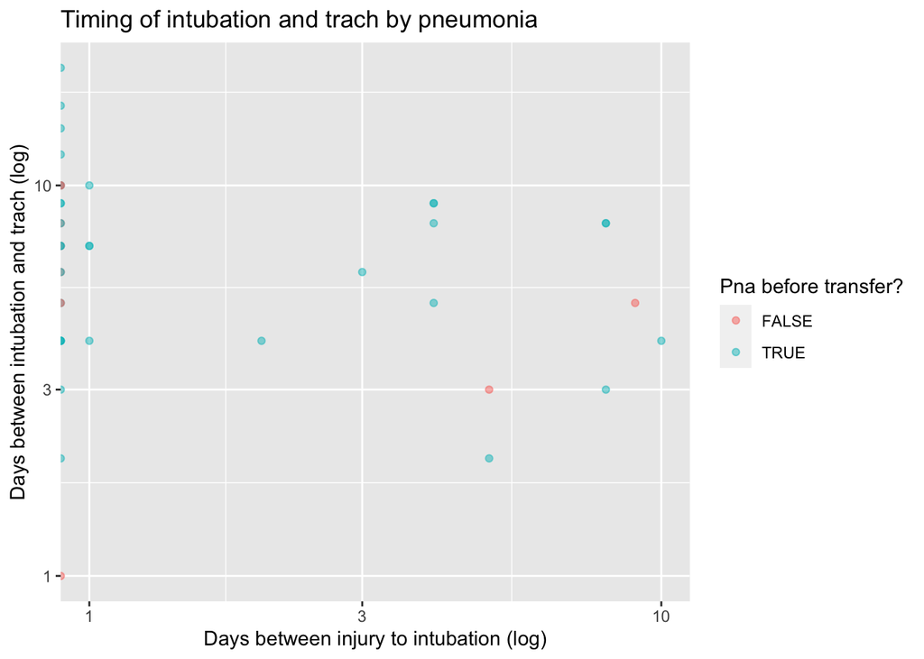

Timing of Trach and Intubation

```r
#note; fig-cap will only appear if you give a label option.

df |>
  ggplot(mapping = aes(x = days_inj_intub,
                       y = days_intub_trach,
                       colour = pna_before_transfer)) +
  geom_point(alpha = 0.5) +
  scale_x_log10() +
  scale_y_log10() +
  labs(
    x = "Days between injury to intubation (log)",
    y = "Days between intubation and trach (log)",
    color = "Pna before transfer?",
    title = "Timing of intubation and trach by pneumonia"
  )
```

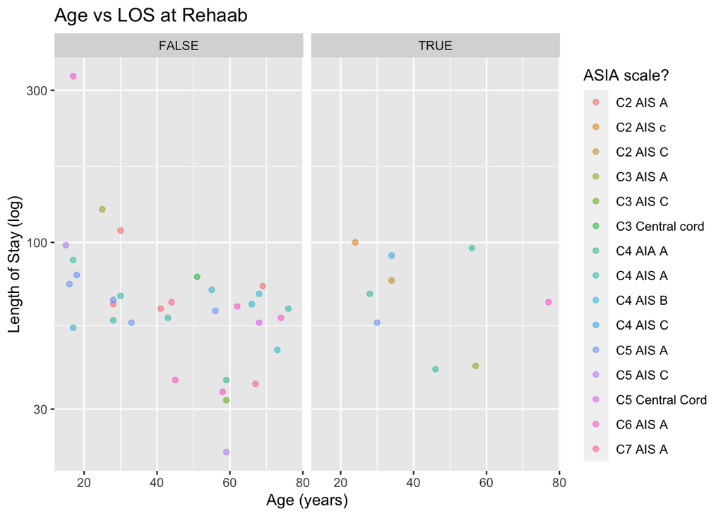

```r
df |>
  ggplot(mapping = aes(x = age,
                       y = days_adm_disch_rehab,
                       colour = asia_class_at_rehab)) +
  scale_y_log10() +
  geom_point(alpha = 0.5) +
  labs(
    x = "Age (years)",
    y = "Length of Stay (log)",
    color = "ASIA scale?",
    title = "Age vs LOS at Rehaab") +
  facet_wrap(~female)
```

TODO: Sankey Diagrams?

//plan: was there internal referral? Is this a way to make pre-admission weaning comparable? //do people who wean faster lower the total length of stay // how frequent was pneumonia, controlling for pneumonia that occured before.

// Outcomes: // Ordinal: decannulate, weaned 24h, wean during day, no wean [1 limitation of trach not vented: could be placement to facility or TBI] // Ordinal: discharge location **** // Cox-regression for length of stay.

//Old data: asia class -> likelihood to wean

//how could you generate useful preliminary data to support an early aggressive weaning protocol. – implicit comparison to historical rates of weaning? //RT flow sheets for data on what is happening.